# Evidence, Framing, and Planning

Week 4 Monday — Chapter 6

NRES 315: Human Dimensions of Fish and Wildlife Management

2026-09-14

## Building from public-trust thinking

**Last week:** Public institutions hold responsibilities to current and future beneficiaries.

**This week:** How do managers use evidence to plan, act, and learn in ways that make those responsibilities visible?

Source: Chapter 6, §§6.1–6.2

## The central question

How does a human-dimensions orientation improve an evidence-based management decision?

At the most basic, it broadens both the evidence managers use and the outcomes they seek.

Source: Chapter 6, §§6.1–6.2

## Evidence and framing

From a management question to a defensible plan.

## A decision needs more than biological evidence

**What is happening?**

- Biological or ecological conditions
- Technical feasibility
- Legal mandates

**What should be done?**

- Economic feasibility
- Social values
- Public knowledge and experience

**Key point:** These evidence sources complement one another; none resolves every management question alone.

Source: Chapter 6, §6.2.1

## Evidence answers different parts of the decision

| Evidence type | A question it can help answer |
| --- | --- |
| Ecological and biological | What condition, risk, or response is occurring? |
| Social and economic | Who is affected, what matters, and what tradeoffs are feasible? |
| Legal and institutional | What authority, duty, or process applies? |
| Local and experiential | What place-based knowledge or implementation concern should shape the plan? |

Source: Chapter 6, §6.2.1.

## Four questions organize a decision

**Why?**

Why manage or conserve this resource?

**Who?**

Which publics, beneficiaries, and partners are involved?

**What?**

What impacts or outcomes are desired?

**How?**

How will the decision be made, carried out, and assessed?

Source: Chapter 6, §6.2

## Research and participation have different jobs

**Research** can describe conditions, relationships, and likely consequences.

**Participation** can reveal values, concerns, local knowledge, and acceptable tradeoffs.

Meaningful participation is more than a legal requirement. It needs a structured process, capable staff, and genuine integration of input.

Source: Chapter 6, §6.2.1

## Evidence-informed does not mean expert-only

Research can reduce uncertainty and test relationships. Participation can clarify values, lived experience, local knowledge, and acceptable tradeoffs.

A defensible process makes both the evidence considered and the role of public input visible.

Source: Chapter 6, §6.2.1.

## Plan–Do–Learn is iterative

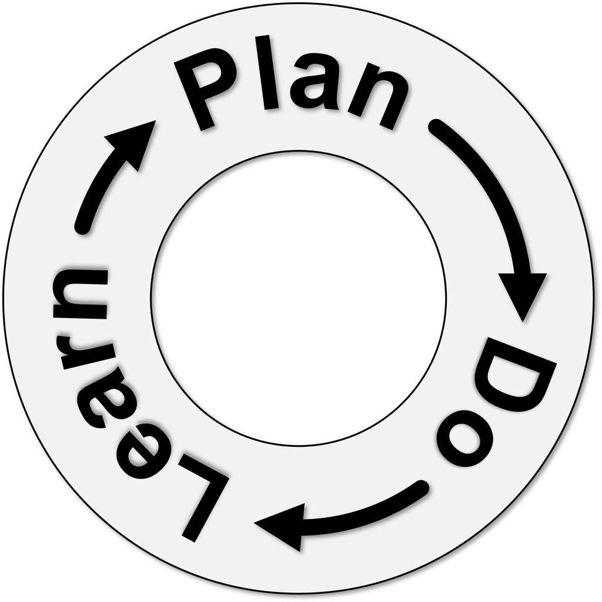

Learning can revise the action, the objectives, or even the original problem frame.

Source: Chapter 6, §6.3 and Figure 6.1

## Structured decision making makes choices inspectable

Structured decision making makes the links explicit among:

- the decision context and problem;
- objectives and measurable outcomes;
- management alternatives; and
- predicted consequences, tradeoffs, and uncertainty.

Source: Chapter 6, §6.3.1.

## Planning turns a broad concern into a choice

Clear framing, objectives, alternatives, and measures.

## Problem framing shapes the whole cycle

How a problem is framed influences:

- who is involved;
- what evidence is gathered;
- which alternatives are considered; and
- how success is measured.

Different frames can produce different, defensible management choices.

Source: Chapter 6, §§6.3–6.4

## A goal gives direction; objectives make it testable

**Goal**

A broad, desired direction for management.

**Objective**

A specific, measurable statement of what the plan intends to achieve.

Source: Chapter 6, §6.3.2.1.

## Objectives, actions, and measures are not interchangeable

**Objective**

The desired change.

*Example:* Improve access.

**Action**

What managers do.

*Example:* Restore a boat ramp.

**Measure**

Evidence of change.

*Example:* Reported ability to access the site.

SMART objectives are Specific, Measurable, Achievable, Relevant, and Time-bound.

Source: Chapter 6, §§6.3.2–6.3.2.2

## A success metric should support a management decision

A useful metric is not merely easy to count. It should be:

- connected to an objective;
- sensitive enough to detect meaningful change;
- feasible to collect and interpret; and
- useful for choosing whether to continue, adjust, or replace an action.

Source: Chapter 6, §6.3.2.2.

## “Do” includes implementation, not just a decision

Once an alternative is chosen, professionals must translate it into action through roles, resources, communication, partnerships, and attention to implementation conditions.

Source: Chapter 6, §6.3.3.

## “Learn” requires monitoring and evaluation

**Monitor**

Collect information about conditions, implementation, and outcomes over time.

**Evaluate**

Interpret that information against objectives to decide what should change.

Learning can change an action, an objective, or the original problem frame.

Source: Chapter 6, §§6.3.4–6.3.4.2.

## Preparing for Friday: Puget Sound

Puget Sound’s long-term recovery effort considers ecological conditions and human well-being together.

Come Friday ready to identify:

- the why, who, what, and how;
- one kind of evidence that matters; and
- one outcome worth monitoring.

Source: Chapter 6, Box 6.2

## Exit check

An agency relies only on biological information to choose an action.

**Which of the four decision questions is most likely to be weakened—and why?**

Source: Chapter 6, §6.2